# IT8010 - IT Project

## World Happiness Report and Relevant Factors

#### Submitted to: Dr. Murat Ozer

#### Submitted by: Muthu Vadivu ShanmugaSundaram

#### Date: 04/14/2021

## Abstract:

Objective

The aim of the study is to identify and investigate if there is a correlation between the happiness score of countries and factors such as Gender Gap, Linguistic Diversity and Scholastic Performance of Students.

Methods

In order to carry out the research, we make use of web scraping with Python and retrieve appropriate indices for each of our variables from official or other reliable data sources from the web. With the help of Python Pandas and Seaborn libraries, we visually represent the data in scatter plots with regression lines and interpret the results. To further confirm our outcome, significance tests are conducted by utilizing Python Scipy library and arriving at a Pearson Correlation Coefficient for the relationships.

Results

Statistically significant moderate positive linear relationship has been found between Happiness Score and Scholastic Performance of students as measured by the PISA score. Likewise, a statistically significant weak negative linear relationship is found between Happiness Score and Linguistic Diversity. On the other hand, no linear relationship is observed between Happiness Score and Gender Gap and this correlation seems statistically insignificant.

Conclusion

The findings indicate that there is a moderate positive linear relationship between Happiness Score of countries and the Scholastic Performance of Students, a weak negative correlation between Happiness Score and Linguistic Diversity and no correlation between Happiness Score and Gender Gap.

## Problem Statement:

Happiness is a very important thing, or perhaps the most important thing, to all of us. Although happiness has always been the ultimate goal of every human being, this had not been discussed or given much attention until recently. With a good understanding of the significance of this element, the Prime Minister of Bhutan proposed the idea of World Happiness Day to the United Nations in 2011.(Layard & Helliwell, 2012) In order to encourage the Governments to measure and improve the happiness of their people, the U.N. General Assembly, subsequently, passed a resolution inviting Governments to make this a criterion while determining ways in achieving and measuring social economic development. As a result, the first World Happiness Report was prepared in 2012 and the report is being published every year from thereon.

“Happiness is a serious business”, says Madhavi Pothukuchi, an editor of a popular Indian Press Company ‘The Print’. (Pothukuchi, 2020) She has further added that the Governments have started looking at this metric more seriously as they are an indication of the prosperity of their country during their term. Moreover, because of the COVID-19 pandemic, the mental well-being of individuals are either negatively impacted or expected to be negatively impacted. This further creates a need for the Government to focus more on the happiness of their people.

In our current project, we plan to study the correlation between Happiness Score of Countries and few important factors such as Gender Gap, Linguistic Diversity of Population and Scholastic Performance of Students as measured by PISA score. If a correlation is found between the happiness score and these characteristics, further researches could be done to identify if there is a cause-effect relationship, which would then bring more focus on these variables and help in guiding national policies.

## Research Questions:

Is there a correlation between Gender Gap and Happiness Score of Countries?

Is there a correlation between Linguistic Diversity of population and Happiness Score of Countries?

Is there a correlation between Scholastic Performance of students and Happiness Score of Countries?

## Literature Review:

#### Visualizing Global Happiness and its Contributing Factors by Xiaohang LI, Pei Xuan LIM, Jia Xian GOH

This paper gathers insights on various components that contribute to the Happiness Index and provides a good understanding of the World Happiness Report published (Li, Lim, & Goh, 2019). The paper includes creation of dashboard with data of close to 150 countries spanning over a decade. In spite of giving a clear visual understanding of various existing measures, this study lacks research on finding any new attributes that contribute to the happiness of population. The authors have, in fact, mentioned that the six variables considered for arriving at this Happiness Score are inadequate and in particular, lacks inclusion of data related to inequality within countries. Our study will examine the variable of Gender Inequality and few other variables that are relevant to the current world situation. Besides, the visualizations presented in this paper are with the data reported prior to 2019 but our research will utilize the happiness report generated in 2020.

#### Measuring and Visualising Global Happiness by Fiona Marshall , Raymond Bond , Shuai Zhang

This study focused more on GDP as indicator of happiness(Marshall, Bond, & Zhang, 2018). Overall, the paper aimed to identify if there was any relationship between wealth and happiness, whether happiness changed over time and if there were other factors affecting happiness. Although there was a strong correlation between GDP and happiness index, the relationship was changing between income ranges. The study concluded that GDP was not the sole impacting variable and there are other elements impacting the index. The recommendation for further research was to study data over a period of time and look for other reasons to explain the outcome. The purpose of our research would be to do something similar to what has been suggested here.

#### The Nordic Exceptionalism: What Explains Why the Nordic Countries are Constantly Among the Happiest in the World by Frank Martela, Bent Greve, Bo Rothstein, Juho Saari

The researchers of this study have analyzed the reasons behind Nordic countries always being on the top ten in the World Happiness Report (Martela, Greve, Rothstein, & Saari, 2020). They have further studied each of the variables in detail with respect to Nordic and Non-Nordic countries and dispelled the common myths. In addition, they have discussed how changing the measurement from life satisfaction to positive emotions could yield a different ranking list. While this research examines the differences of the key characteristics between Nordic and other countries and specifies that there are many other factors contributing to the happiness of Nordic countries than the six that are taken into consideration, there is no study done on the same. Our study will focus on identifying the correlation of other attributes to the happiness score.

## Data Collection:

Data for this study is collected by scraping data from the Web using Python Beautiful Soup. Although the code fetches data from different websites like wikipedia, manual verification of the data was conducted against the data in the official websites. More information on the data source of each of the variable can be found below,

#### Happiness Score of Countries

United Nations Sustainable Development Solutions Network publishes the World Happiness Report every year, based on the resolution adopted by UN General Assembly in July 2011, in order to help guide public policy (World happiness report 2020, 2020). World Happiness Report use data that come from the Gallup World Poll surveys. These surveys ask main life evaluation questions to the respondents by requesting them to think of a ladder and rate their lives on a scale of 0 to 10 (where 0 is the worst possible life and 10 is the best possible life). The rankings and scores of countries are derived from the survey scores with the use of Gallup weights, from nationally representative samples. The levels of GDP, life expectancy, generosity, social support, freedom, and corruption - are estimated to contribute to make life evaluations higher. Typically, the annual sample of each country is 1000 people. The sample size would be 3000 for countries which had surveys each year. This sample size is large enough to provide a good estimate at the national level. These are confirmed by 95% confidence levels.

Index: World Happiness Index 2020

Organization Responsible: United Nations Sustainable Development Solutions Network

Official Website: https://worldhappiness.report/

Original Data Source: World Happiness Report 2020

Data Scraped from: https://en.wikipedia.org/wiki/World_Happiness_Report

#### Gender Gap

First introduced by the World Economic Forum in 2006, the Global Gender Gap Index is a framework to capture the scale of gender-based disparities and the progress that happens over years (The global gender gap index 2020, 2020). The index benchmarks national gender gaps on economic, education, health and political criteria, and provides country rankings that allow for effective comparisons across regions and income groups. The quantitative analysis and methodology behind these rankings serve as a basis for planning measures that could effectively reduce gender gaps. The procedure to determine index scores is designed in such a way as to count situations in which men are disadvantaged relative to women as "equal". This report covers as many countries as possible and as of 2020 this includes data from 153 countries out of which 107 have been consistently included from the first edition of this publication.

Index: Global Gender Gap Index 2020

Organization Responsible: The World Economic Forum

Official Website: https://reports.weforum.org/global-gender-gap-report-2020/the-global-gender-gap-index-2020/

Original Data Source: Global Gender Gap Report 2020

Data Scraped from: https://en.wikipedia.org/wiki/Global_Gender_Gap_Report

#### Linguistic Diversity

Greenberg's Diversity Index, also known as the Linguistic Diversity Index, measures the language diversity in various countries. It is the probability that two randomly selected people from the population will have different mother tongues (Linguistic diversity index.2021). While a 0 indicates that everyone has the same mother tongue, a 1 indicates no two people have the same mother tongue.

Index: Greenberg's Diversity Index or Linguistic Diversity Index 2021

Organization Responsible: Not known

Official Website: NA

Orginial Data Source: Pew Research Center

Data Scraped from:https://worldpopulationreview.com/country-rankings/most-diverse-countries

#### Scholastic Performance of Students

PISA stands for Programme for International Student Assessment conducted by the Organisation for Economic Co-operation and Development. It measures the ability of 15-year-old students across various countries to use their reading, mathematics and science knowledge and skills to meet real-life challenges. The knowledge and skills of students are measured through an internationally agreed upon metric. For the 2018 PISA study, a two-stage sampling procedure was conducted (Programme for international student assessment - PISA.). At first a representative sample of at least 150 schools were selected, taking into account factors such as location (state or province; but also whether the school is located in a rural area, town or city) and level of education. In the next stage, close to 42 15-year-old students were randomly selected from each school to take the assessment. Most countries assessed between 4000 and 8000 students. Students selected to take the PISA assessment received sampling weights so as to represent the entire PISA-eligible cohort. It is, therefore, considered to be the most reliable and comprehensive indicator of student’s capability across nations and it serves as a tool for countries to understand and fine-tune their educational policies. Hence, this score can be used as an indicator of Scholastic Performance of Students in a country for the purpose of our research.

Index: Programme for International Student Assessment (PISA) 2018 Score (Most recent)

Organization Responsible: Organisation for Economic Co-operation and Development

Official Website: https://www.oecd.org/pisa/

Original Data Source: PISA Report 2018

Data Scraped from:https://factsmaps.com/pisa-2018-worldwide-ranking-average-score-of-mathematics-science-reading/comment-page-1/

## Data Processing:

Once data is scraped from the above sources using Python Beautiful Soup, we will start focusing on each of the research questions. Using Pandas Dataframe, data for each of the variables in the corresponding research question will be merged into a single dataframe, in such a way that only countries that match between the report of both the variables in the question are considered for the study. A scatterplot will then be designed with a regression line, to display the relationship between the two variables of interest. A significance test will then be conducted to confirm the results obtained from the scatter plot. This can be done by arriving at the Pearson Correlation Coefficient.

#### Interpreting Scatter Plots:

A scatterplot displays a graphical relationship between two sets of data. Each dot in a scatter plot represents a single data point. A regression line (a straight line) is a line of best fit. If the line slopes upward as we move from left to right, this will specify a positive relationship between X and Y. As the X-values increase, the Y-values tend to increase. On the other hand, if the line slopes downward as we move from left to right, this indicates a negative relationship between X and Y (Deborah J, 2016). In this case, as the X-values increase, the Y-values tend to decrease. If the line is horizontal, then there exists no relationship between X and Y. It may be worthy to note how close the data points are to the line of best fit. If all or most of the data points lie on the line of best fit, the correlation is expected to be strong. But if most of the points lie above or below the line, the correlation is said to be weak as there are many outliers to the line.

#### Interpreting Pearson Correlation Coefficient:

Pearson Correlation coefficient is a helpful way to examine the direction and strength of linear relationships between two variables.

Direction & Strength: The direction of the relationship can be interpreted by the sign of the relationship. If the coefficient is positive, there is a positive correlation between the two variables and if the coefficient is negative, there is a negative correlation between the variables (Interpret the key results for correlation.). The correlation coefficient can range in value from −1 to +1. The larger the absolute value of the coefficient, the stronger the relationship between the variables.

Statistical Significance: The p-value should be compared to the significance level (alpha level) we have decided. The alpha level we use for this study is 0.05 which works well for most case. The p-value tells us whether the correlation coefficient is significantly different from 0.

P-value ≤ α: The correlation is statistically significant

If the p-value is less than or equal to the significance level, then we can conclude that the correlation is different from 0.

P-value > α: The correlation is not statistically significant

If the p-value is greater than the significance level, then we cannot conclude that the correlation is different from 0.

## Python Code

```python
#Import all the required packages
import pandas as pd
import numpy as np
import scipy as sp
import seaborn as sns
import xlrd
import requests
import re
from scipy.stats import ttest_ind
from matplotlib import pyplot as plt
%matplotlib inline
from bs4 import BeautifulSoup
```

### Research Question-1

Is there a correlation between Gender Gap and Happiness Score of Countries?

#### Research hypotheses:

H0 (Null Hypothesis) - There is no correlation between Gender Gap and Happiness Score of Countries.

H1 (Alternative Hypothesis) - There is a correlation between Gender Gap and Happiness Score of Countries.

```python
#To retrieve data from Wikipedia on World Happiness Index

url1 = 'https://en.wikipedia.org/wiki/World_Happiness_Report'

response1 = requests.get(url1)
content1 = response1.content

soup1 = BeautifulSoup(content1, 'lxml')

table1 = soup1.find("table",{'class':'wikitable sortable'})


td_len1 = len(table1.findAll('td'))
i = 0
j = 0

country = []
hap_score = []

for i in range(1, td_len1, 9):
    str1 = table1.findAll('td')[i].get_text(strip=True)
    country.append(str1)

f1=open('gggi.txt','w+')
for j in range(2, td_len1-1, 9):
    str2 = table1.findAll('td')[j].get_text(strip=True)
    f1.write(str2+"\n")
    hap_score.append(str2)

#Create a dataframe and add the list of values retrieved above to the dataframe
df_HappinessIndex = pd.DataFrame()
df_HappinessIndex['Country'] =  country
df_HappinessIndex['Happiness Score'] = hap_score
df_HappinessIndex
```

|  | Country | Happiness Score |
| --- | --- | --- |
| 0 | Finland | 7.809 |
| 1 | Denmark | 7.646 |
| 2 | Switzerland | 7.560 |
| 3 | Iceland | 7.504 |
| 4 | Norway | 7.488 |
| ... | ... | ... |
| 148 | Central African Republic | 3.476 |
| 149 | Rwanda | 3.312 |
| 150 | Zimbabwe | 3.299 |
| 151 | South Sudan | 2.817 |
| 152 | Afghanistan | 2.567 |

153 rows × 2 columns

```python
#To retrieve data from Wikipedia on the Global Gender Gap Index for each country
url2 = 'https://en.wikipedia.org/wiki/Global_Gender_Gap_Report'

response2 = requests.get(url2)
content2 = response2.content

soup2 = BeautifulSoup(content2, 'lxml')

table2 = soup2.find("table",{'class':'wikitable sortable'})

no_of_rows = len(table2.findAll('td'))

countries = []
gggi = []

#To fetch the country names and the Global Gender Gap Score of the country in 2020
for i in range(0, no_of_rows, 16):
    str3 = table2.findAll('td')[i].get_text(strip=True)
    countries.append(str3)

for j in range(-1, no_of_rows-1, 16):
    str4 = table2.findAll('td')[j].get_text(strip=True)
    gggi.append(str4)

#Create a dataframe and add the list of values retrieved above to the dataframe
df_GenderGapIndex = pd.DataFrame()
df_GenderGapIndex['Country'] =  countries
df_GenderGapIndex['Global Gender Gap Score'] = gggi
indexN = df_GenderGapIndex[df_GenderGapIndex['Global Gender Gap Score']=="N/A"].index
df_GenderGapIndex.drop(indexN, inplace=True)
df_GenderGapIndex
```

|  | Country | Global Gender Gap Score |
| --- | --- | --- |
| 0 | Albania | 0.730 |
| 1 | Algeria | 0.769 |
| 2 | Angola | 0.634 |
| 3 | Argentina | 0.660 |
| 4 | Armenia | 0.746 |
| ... | ... | ... |
| 142 | Venezuela | 0.737 |
| 143 | Vietnam | 0.713 |
| 144 | Yemen | 0.700 |
| 145 | Zambia | 0.494 |
| 146 | Zimbabwe | 0.731 |

145 rows × 2 columns

```python
#Merge columns from both the dataframes and assign to a new dataframe based on Country
df_rq1 = pd.merge(df_HappinessIndex, df_GenderGapIndex, how = 'inner', on= 'Country')

#Print the dataframe
df_rq1["Happiness Score"] = pd.to_numeric(df_rq1["Happiness Score"], downcast="float")
df_rq1["Global Gender Gap Score"] = pd.to_numeric(df_rq1["Global Gender Gap Score"], downcast="float")
df_rq1

#Export the dataframe to csv
df_rq1.to_csv('ITProjRQ1.csv')
```

Now, we have the data set ready for our first research question.

We will display a scatter plot with a regression line to find if there is a correlation.

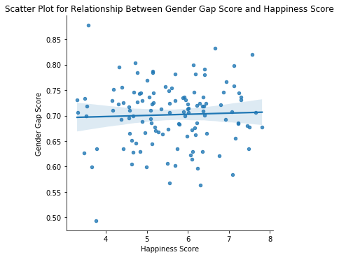

```python
#To draw a scatter plot for the relationship
sns.lmplot('Happiness Score', 'Global Gender Gap Score', data=df_rq1, fit_reg=True,
           scatter_kws={"marker":"D", "s": 20})
plt.title('Scatter Plot for Relationship Between Gender Gap Score and Happiness Score')
plt.xlabel('Happiness Score')
plt.ylabel('Gender Gap Score')
plt.show()
```

#### Interpretation of the visualization:

As per the visualization, there is no correlation between Gender Gap Score and Happiness Score of Countries.

### Pearson Correlation Coefficient:

```python
from scipy import stats
stats.pearsonr(df_rq1['Happiness Score'], df_rq1['Global Gender Gap Score'])
```

```
(0.04016088303538621, 0.6565503849926394)
```

### Research Question-2

Is there a correlation between Linguistic Diversity and Happiness Score of Countries?

#### Research hypotheses:

H0 (Null Hypothesis) - There is no correlation between Linguistic Diversity and Happiness Score of Countries.

H1 (Alternative Hypothesis) - There is a correlation between Linguistic Diversity and Happiness Score of Countries.

```python
#To retrieve data from csv file on the Global Gender Gap Index for each country

df_DiversityIndex = pd.read_csv("DiversityIndex.csv", usecols=['country','GI'])
df_DiversityIndex = df_DiversityIndex.rename(columns={"country": "Country", "GI": "Diversity Score"})
df_DiversityIndex['Country'] = df_DiversityIndex['Country'].str.capitalize()
print(df_DiversityIndex)
```

```
                Country  Diversity Score
0                  Chad           0.8514
1              Cameroon           0.8426
2               Nigeria           0.8306
3                  Togo           0.8118
4                 Kenya           0.8091
..                  ...              ...
177             Uruguay           0.0000
178  Dominican republic           0.0000
179               Haiti           0.0000
180              Rwanda           0.0000
181           Argentina           0.0000

[182 rows x 2 columns]
```

```python
#Merge columns from both the dataframes and assign to a new dataframe based on the country
df_rq2 = pd.merge(df_HappinessIndex, df_DiversityIndex, how = 'inner', on= 'Country')

#Print the dataframe
df_rq2["Happiness Score"] = pd.to_numeric(df_rq2["Happiness Score"], downcast="float")
df_rq2["Diversity Score"] = pd.to_numeric(df_rq2["Diversity Score"], downcast="float")
df_rq2
```

|  | Country | Happiness Score | Diversity Score |
| --- | --- | --- | --- |
| 0 | Finland | 7.809 | 0.1119 |
| 1 | Denmark | 7.646 | 0.1422 |
| 2 | Switzerland | 7.560 | 0.4960 |
| 3 | Iceland | 7.504 | 0.0678 |
| 4 | Norway | 7.488 | 0.0581 |
| ... | ... | ... | ... |
| 118 | Botswana | 3.479 | 0.3670 |
| 119 | Tanzania | 3.476 | 0.7353 |
| 120 | Rwanda | 3.312 | 0.0000 |
| 121 | Zimbabwe | 3.299 | 0.3187 |
| 122 | Afghanistan | 2.567 | 0.6478 |

123 rows × 3 columns

With the above data, we will plot a graph to verify if a correlation exists

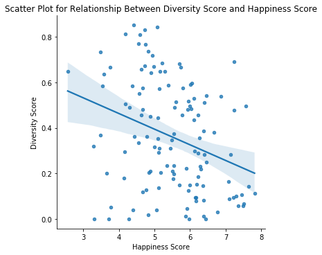

```python
#To draw scatter plot for the relationship
sns.lmplot('Happiness Score', 'Diversity Score', data=df_rq2, fit_reg=True,
           scatter_kws={"marker":"D", "s": 20})
plt.title('Scatter Plot for Relationship Between Diversity Score and Happiness Score')
plt.xlabel('Happiness Score')
plt.ylabel('Diversity Score')
plt.show()
```

#### Interpretation of the visualization:

According to the visualization, there exists a negative correlation between Linguistic Diversity of a country and Happiness Score. That is, when the linguistic diversity is high, the happiness score score is low and vice versa.

### Pearson Correlation Coefficient:

```python
from scipy import stats
stats.pearsonr(df_rq2['Happiness Score'], df_rq2['Diversity Score'])
```

```
(-0.3127376185181817, 0.0004286589766090318)
```

#### Interpretation:

In this case, r = -0.3127 and p-value = 0.0004. A negative r value of -0.3127 denotes a weak negative relationship between the two variables and a p-value of 0.0004 denotes a statistically significant result. Therefore, we reject the null hypothesis in favor of the alternative hypothesis and conclude that there is a weak negative correlation between the variables Happiness Score and Diversity Score.

### Research Question - 3

Is there a correlation between Scholastic Performance of students and Happiness Score of Countries?

#### Research hypotheses:

H0 (Null Hypothesis) - There is no correlation between Scholastic Performance of Students and Happiness Score of Countries.

H1 (Alternative Hypothesis) - There is a correlation between Scholastic Performance of Students and Happiness Score of Countries.

Retrieve data on Average PISA score of countries and export to file

url3 = 'https://factsmaps.com/pisa-2018-worldwide-ranking-average-score-of-mathematics-science-reading/comment-page-1/'

soup3 = BeautifulSoup(content3, 'lxml')

with open ("soup3.html","w", encoding='utf-8') as file: file.write(str(soup3))

```python
imported_soup = BeautifulSoup(open("soup3.html"), "html.parser")

table3 = imported_soup.find("figure",{'class':'wp-block-table'})

td_len3 = len(table3.findAll('td'))

countries_pisa = []
pisa_avg = []

for i in range(1, td_len3, 3):
    str5 = table3.findAll('td')[i].get_text(strip=True)
    countries_pisa.append(str5)

for j in range(2, td_len3, 3):
    str6 = table3.findAll('td')[j].get_text(strip=True)
    pisa_avg.append(str6)

#Create a dataframe and add the list of values retrieved above to the dataframe
df_PISA = pd.DataFrame()
df_PISA['Country'] =  countries_pisa
df_PISA['PISA Score'] = pisa_avg
df_PISA.iat[0,0]='China'
df_PISA
```

|  | Country | PISA Score |
| --- | --- | --- |
| 0 | China | 578.7 |
| 1 | Singapore | 556.3 |
| 2 | Macao | 542.3 |
| 3 | Hong Kong, China | 530.7 |
| 4 | Estonia | 525.3 |
| ... | ... | ... |
| 72 | Morocco | 368.0 |
| 73 | Panama | 365.0 |
| 74 | Kosovo | 361.3 |
| 75 | Philippines | 350.0 |
| 76 | Dominican Republic | 334.3 |

77 rows × 2 columns

```python
#Merge columns from both the dataframes and assign to a new dataframe based on the state value
df_rq3 = pd.merge(df_HappinessIndex, df_PISA, how = 'inner', on= 'Country')

#Print the dataframe
df_rq3["Happiness Score"] = pd.to_numeric(df_rq3["Happiness Score"], downcast="float")
df_rq3["PISA Score"] = pd.to_numeric(df_rq3["PISA Score"], downcast="float")
df_rq3
```

|  | Country | Happiness Score | PISA Score |
| --- | --- | --- | --- |
| 0 | Finland | 7.809 | 516.299988 |
| 1 | Denmark | 7.646 | 501.000000 |
| 2 | Switzerland | 7.560 | 498.000000 |
| 3 | Iceland | 7.504 | 481.299988 |
| 4 | Norway | 7.488 | 496.700012 |
| ... | ... | ... | ... |
| 67 | Albania | 4.883 | 419.700012 |
| 68 | Lebanon | 4.772 | 376.700012 |
| 69 | Georgia | 4.673 | 387.000000 |
| 70 | Jordan | 4.633 | 416.000000 |
| 71 | Ukraine | 4.561 | 462.700012 |

72 rows × 3 columns

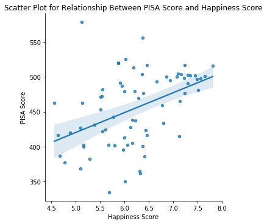

```python
#To draw a scatter plot with a regression line to display the relationship between variables
sns.lmplot('Happiness Score', 'PISA Score', data=df_rq3, fit_reg=True,
           scatter_kws={"marker":"D", "s": 20})
plt.title('Scatter Plot for Relationship Between PISA Score and Happiness Score')
plt.xlabel('Happiness Score')
plt.ylabel('PISA Score')
plt.show()
```

#### Interpretation of the visualization:

The visualization shows a positive correlation between Happiness Score and Scholastic Performance of Students as measured by PISA. Meaning, as the happiness score increases, the scholastic performance of students increases.

### Pearson Correlation Coefficient:

```python
from scipy import stats
stats.pearsonr(df_rq3['Happiness Score'], df_rq3['PISA Score'])
```

```
(0.44700009807398233, 8.275166607389219e-05)
```

#### Interpretation:

Based on the r value and p-value result obtained above we reject the null hypothesis in favor of the alternative hypothesis and conclude that there is a statistically significant moderate positive linear correlation between Happiness Score and Scholastic Performance of students as measured by the PISA score.

## Results:

In this research, we investigated the data for different variables/indices acorss countries to find if there is any correlation between them and happiness score. From the visualizations, we were able to find the type of correlation between the variables we examined and the happiness score. We were also able to confirm the same by conducting Significance Tests with Pearson Correlation Coefficient. The tests conducted were at a significance level of 0.05. In other words a confidence level of 95%.

The results indicate that there is a moderate positive correaltion between Happiness Score and Scholastic Performance of Students and a weak negative correlation between Happiness Score and Linguistic Diversity. However, no correlation is observed between Happiness Score and Gender Gap.

## Discussion:

This study demonstrates a correlation between happiness score and two of the three variables we studied, namely Scholastic Performance of Students and Linguistic Diversity. While there is a moderate positive correlation between Scholastic Performance of Students and Happiness Score, there is a weak negative correlation between Linguistic Diversity and Happiness Score. But in contrary to the hypothesized association, there is no correlation observed between Gender Gap and Happiness Score. These results provide insights on how factors such as these impact the happiness of people and these should be taken into account when the government makes decisions on variouis policies.

However, there are some limitations to this study. It focuses only on linear relationship between variables. Future studies on this topic could analyse and establish if there is a causal relationship between these variables. One other limiation is that the data taken into consideration do not include all the countries across the globe. Moreover, the variables that were investigated are of interest to the researcher and does not have any other significance as the literature lacks information on what kind of social and economic variables that are needed to be studied. Further researches could also be done to identify the variables that are common to the happiest countries and perform independent study on the correlation between those variables and happiness index.

## Conclusion:

Although GDP might be thought of as the best indicator of a nation’s happiness by some, the World Happiness Report has shown that it need not necessarily be true. It is undeniable that GDP is a good indicator of the standard of living of a society and it has some influence on the happiness of people in a country but it is not all that matters. There are various social factors that play a key role in the happiness of people across countries. It is interesting to note that there is a moderate/weak correlation between happiness and factors such as Linguistic Diversity and Scholastic Performance of Students. However, it is surprising to see that there is no correlation between happiness score and gender gap. Studying more relevant variables could help policy makers in understanding the factors that influence the well-being of people in their country.

## References:

Layard, R., & Helliwell, J. (2012). First world happiness report launched at the united nations. Retrieved from https://www.earth.columbia.edu/articles/view/2960

Pothukuchi, M. (2020, -03-20T12:17:29+00:00). Happiness is serious business. just look at the world happiness report. Retrieved from https://theprint.in/features/happiness-is-serious-business-just-look-at-the-world-happiness-report/384283/

Li, X., Lim, P. X., & Goh, J. X.Visualizing global happiness and its contributing factors

Marshall, F. M., Bond, R. B., & Zhang, S. (2018). Measuring and visualising global happiness BCS Learning & Development. doi:10.14236/ewic/hci2018.210

Martela, F., Greve, B., Rothstein, B., & Saari, J.The nordic exceptionalism: What explains why the nordic countries are constantly among the happiest in the world

World happiness report 2020. Retrieved from https://worldhappiness.report/ed/2020/

The global gender gap index 2020. (). Retrieved from https://reports.weforum.org/global-gender-gap-report-2020/the-global-gender-gap-index-2020/

Linguistic diversity index. (2021). Retrieved from https://en.wikipedia.org/w/index.php?title&#61;Linguistic_diversity_index&amp;oldid&#61;1002738555

Programme for international student assessment - PISA. Retrieved from https://www.oecd.org/pisa/

Deborah J, R.Statistics workbook for dummies Dummies. Retrieved from https://www.dummies.com/education/math/statistics/how-to-interpret-a-scatterplot/

Interpret the key results for correlation. Retrieved from https://support.minitab.com/en-us/minitab-express/1/help-and-how-to/modeling-statistics/regression/how-to/correlation/interpret-the-results/